# Calculating Warm Core Ring Metrics

Sarah Salois

10/14/2021

## Setting up your environment

> Import libraries and data

```r
library(geosphere)
library(dplyr)
library(ggplot2)
library(car) # function Anova
library(patchwork)
library(swfscMisc)

df <- read.csv('ring_data.csv')
df<- df[,-1]
```

## Modify data

> The following code sets up our dataframe with place holders for metrics that will be calculated and included

```r
df$id <- as.character(df$id)
ringnames <- unique(df$id)
# Initiate columns to add
df$weeks_old <- NA
df$days_old <- NA
df$subarea <- NA # nafo
df$score <- NA # system state info
```

Add in information about system state as defined in Paul Rago’s work (2020)

```r
locs1 <- which(df$year == 2011)
df[locs1,12] <- 'A'
locs2 <- which(df$year == 2012)
df[locs2,12] <- 'A'
locs3 <- which(df$year == 2013)
df[locs3,12] <- 'P'
locs4 <- which(df$year == 2014)
df[locs4,12] <- 'A'
locs5 <- which(df$year == 2015)
df[locs5,12] <- 'P'
locs6 <- which(df$year == 2016)
df[locs6,12] <- 'P'
locs7 <- which(df$year == 2017)
df[locs7,12] <- 'G'
locs8 <- which(df$year == 2018)
df[locs8,12] <- 'G'
locs9 <- which(df$year == 2019)
df[locs9,12] <- 'G'
locs10 <- which(df$year == 2020)
df[locs10,12] <- NA
```

## Calculate first metric : Ages of rings

> This bit of code calculates the age of each ring in terms of weeks old and days old.

```r
for(i in 1:length(ringnames)){
  tmp2 <- subset(df, id == ringnames[i])
  for(j in 1:length(tmp2[,1])){
    tmp2[j, 9] <-  (j)
    tmp2[j, 10] <- ((tmp2[j,9]+1) - tmp2[1, 9])*7
    locs <- which(df$id == ringnames[i])
    df$weeks_old[locs] <- tmp2[,9]
    df$days_old[locs] <- tmp2[,10]
  }
 }


# calculate the max days old for each ring, age of demise == max(days_old)

# set up matrix to hold only ring information pertaining to date of demise
demise <- matrix(nrow = length(ringnames), ncol = ncol(df))

for (i in 1:length(ringnames)){
  ring <- subset(df, id == ringnames[i]) # create a subset for each ring
  dtmp <- subset(ring, weeks_old == max(weeks_old)) # isolate last week
  demise[i,] <- as.matrix(dtmp) # place into holding matrix
}
colnames(demise) <- colnames(df) # name columns
demise <- as.data.frame(demise)

head(df)
```

```
##      id year week       date    lon   lat     area   radius weeks_old days_old
## 1 T2010 2011    1 2011-01-03 -62.85 41.98 17359.99 74.33610         1        7
## 2 T2010 2011    2 2011-01-10 -62.85 42.01 18133.01 75.97313         2       14
## 3 T2010 2011    3 2011-01-17 -62.88 42.00 17683.99 75.02659         3       21
## 4 T2010 2011    4 2011-01-24 -62.86 41.99 17830.87 75.33752         4       28
## 5 T2010 2011    5 2011-01-31 -62.91 42.02 18063.17 75.82668         5       35
## 6 T2010 2011    6 2011-02-07 -62.85 42.01 17291.07 74.18840         6       42
##   subarea score
## 1      NA     A
## 2      NA     A
## 3      NA     A
## 4      NA     A
## 5      NA     A
## 6      NA     A
```

```r
head(demise)
```

```
##      id year week       date    lon   lat     area   radius weeks_old days_old
## 1 T2010 2011    8 2011-02-21 -64.21 41.89  4888.01 39.44492         8       56
## 2 W2010 2011    9 2011-03-02 -56.12 41.15  9589.59 55.24908         9       63
## 3 h2010 2011   20 2011-05-20 -74.02 36.31   8787.5 52.88807        20      140
## 4 j2010 2011   10 2011-03-11 -59.32 40.01 44884.96 119.5296         9       63
## 5 B2011 2011    5 2011-02-04 -65.92 39.82  7118.85 47.60252         6       42
## 6 F2011 2011   15 2011-04-15 -66.17 39.13  8228.35 51.17778        14       98
##   subarea score
## 1    <NA>     A
## 2    <NA>     A
## 3    <NA>     A
## 4    <NA>     A
## 5    <NA>     A
## 6    <NA>     A
```

## Focus on rings West of -65 the fishing season

```r
# all rings that exist west of -65
shelf_rings <-  subset(df, lon <= -65.00)
# all rings that exist during fishing weeks and are west of -65
shelf_rings_fs <- subset(shelf_rings, week %in% c(18:44))
# (fs == fishing season)
```

Examine differences in the number of rings across each of the categories we have just created

**(i) Total number of rings:**

```
## [1] 281
```

**(ii) Number of rings on shelf:**

```
## [1] 123
```

**(iii) Number of rings on shelf during the fishing season:**

```
## [1] 99
```

> Below is a visual representation of the number of rings West of -65 degrees in the years 2011 through 2020.

The chunk of code summarizes the color of each bar represents the ‘score’ of the system state that year was ascribed via Paul Rago’s (2020) analysis. Note, the extent of P. Rago’s analysis is 2011:2019 (excluding 2020).

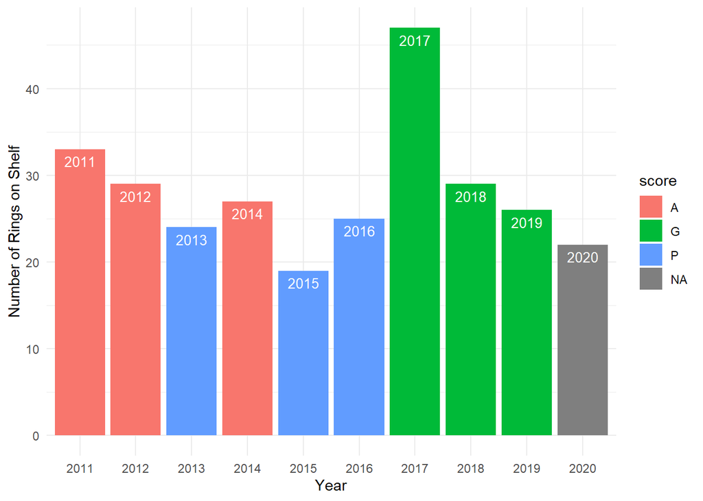

```
## Anova Table (Type III tests)
##
## Response: number
##              Sum Sq Df F value    Pr(>F)
## (Intercept) 2640.33  1 53.2803 0.0003371 ***
## score        196.22  2  1.9798 0.2186365
## Residuals    297.33  6
## ---
## Signif. codes:  0 '***' 0.001 '**' 0.01 '*' 0.05 '.' 0.1 ' ' 1
```

```
## Anova Table (Type III tests)
##
## Response: days_old
##                 Sum Sq  Df F value    Pr(>F)
## (Intercept)      74504   1 23.4763 2.131e-06 ***
## as.factor(year)  55757   9  1.9521   0.04507 *
## Residuals       860039 271
## ---
## Signif. codes:  0 '***' 0.001 '**' 0.01 '*' 0.05 '.' 0.1 ' ' 1
```

## Visualize: age data

> The following plots look at the frequency of ages of rings that hit the shelf during the fishing season

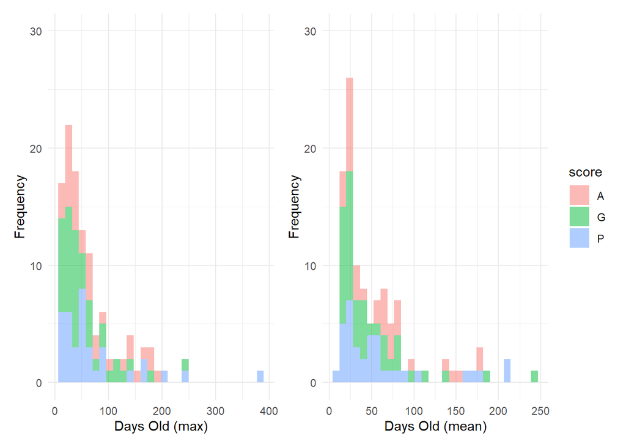

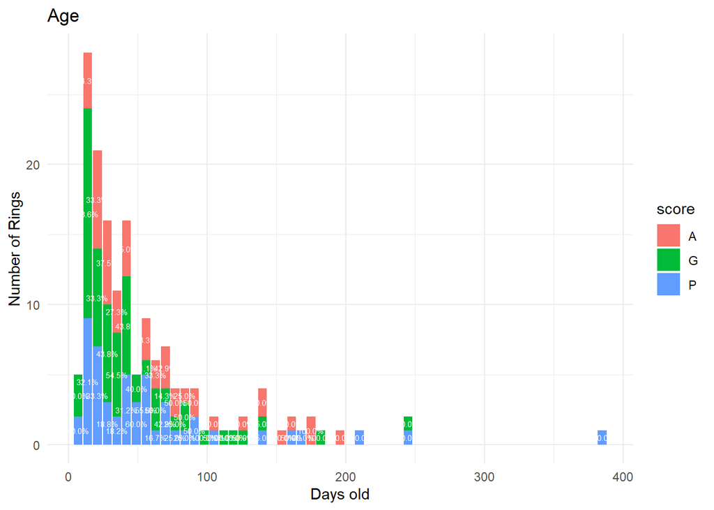

### Quantify

Perfom a quick Anova to test differences between the maxium age of ring across system states:

```r
aov1.3 <- aov(days_old ~ score, data = demise)
Anova(aov1.3, type = 'III')
```

```
## Anova Table (Type III tests)
##
## Response: days_old
##             Sum Sq  Df  F value  Pr(>F)
## (Intercept) 389402   1 122.0481 < 2e-16 ***
## score        22236   2   3.4847 0.03213 *
## Residuals   816784 256
## ---
## Signif. codes:  0 '***' 0.001 '**' 0.01 '*' 0.05 '.' 0.1 ' ' 1
```

```r
TukeyHSD(aov1.3)
```

```
##   Tukey multiple comparisons of means
##     95% family-wise confidence level
##
## Fit: aov(formula = days_old ~ score, data = demise)
##
## $score
##           diff         lwr       upr     p adj
## G-A -16.391165 -35.7061143  2.923783 0.1141181
## P-A   4.986286 -16.4610000 26.433571 0.8475532
## P-G  21.377451   0.5305316 42.224370 0.0429936
```

Here we see which specific groups’s means (compared with each other) are different. There is a significant difference (p = 0.04) between **Good years** and **Poor years**.

## Ring Occupancy

> The following figures explore ring occupancy for rings existing West of -65 during the fishing season

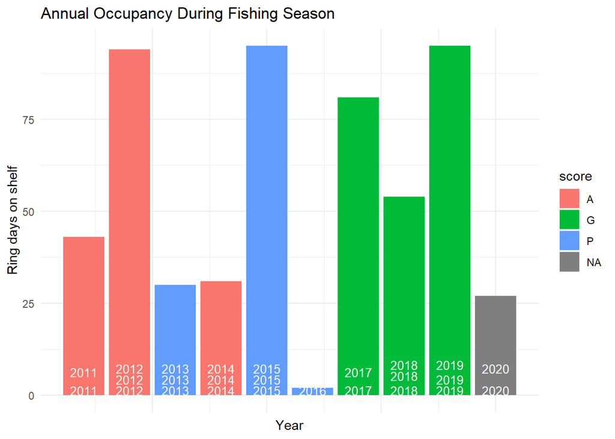

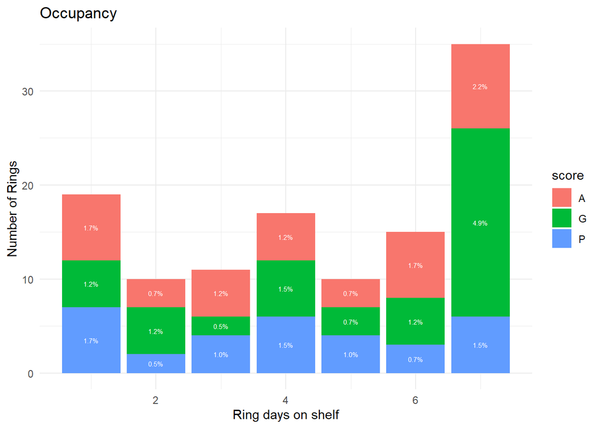

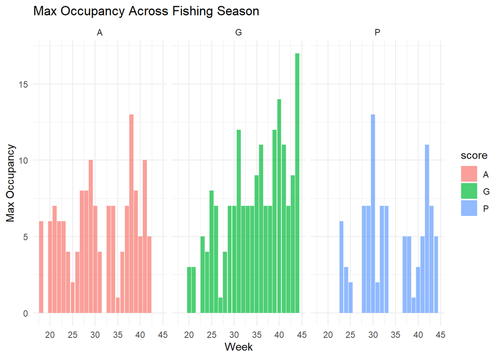

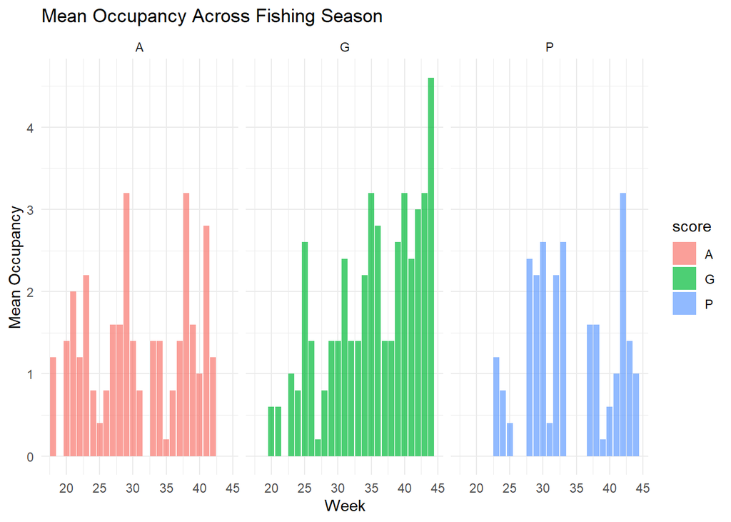

Quick ANOVA to test differences:

```r
# Quantify
aov2.1 <- aov(timeshelf ~ score, data = occ)
Anova(aov2.1, type = 'III')
```

```
## Anova Table (Type III tests)
##
## Response: timeshelf
##              Sum Sq   Df F value    Pr(>F)
## (Intercept)   69.69    1 31.3421 2.674e-08 ***
## score         13.28    2  2.9861   0.05086 .
## Residuals   2694.87 1212
## ---
## Signif. codes:  0 '***' 0.001 '**' 0.01 '*' 0.05 '.' 0.1 ' ' 1
```

```r
aov2.1 <- aov(timeshelf ~ score, data = occ[which(occ$timeshelf>0),])
Anova(aov2.1, type = 'III')
```

```
## Anova Table (Type III tests)
##
## Response: timeshelf
##             Sum Sq  Df  F value Pr(>F)
## (Intercept) 723.69   1 148.0431 <2e-16 ***
## score        21.95   2   2.2456 0.1105
## Residuals   557.28 114
## ---
## Signif. codes:  0 '***' 0.001 '**' 0.01 '*' 0.05 '.' 0.1 ' ' 1
```

```r
TukeyHSD(aov2.1)
```

```
##   Tukey multiple comparisons of means
##     95% family-wise confidence level
##
## Fit: aov(formula = timeshelf ~ score, data = occ[which(occ$timeshelf > 0), ])
##
## $score
##           diff        lwr       upr     p adj
## G-A  0.6923077 -0.4505514 1.8351668 0.3246919
## P-A -0.3389423 -1.5912652 0.9133806 0.7968462
## P-G -1.0312500 -2.2398646 0.1773646 0.1105589
```

## Digging deeper

It is clear from the above plots that ‘Good’ years (years with higher than average catch) are associated with a higher frequency of shorter lived WCRs. More specifically, there was not a significant difference in number of rings per year (as expected re: Gangopadhyay_ea_20), however, there appears to be a difference in the maximum age of rings in good vs bad years - with bad years having more longer lived rings.

> The next question to consider is whether this difference in age is driven by a difference in the origin (location of birth) of these rings and if these difference also show a signal of ‘system state’.

Silva_ea_20 found that rings born in Zone 2 and demised in zone 1 (Z2:Z1) had the highest survival probability. Additionally, WCRs last seen or demised in Zone 1 had a higher survival probability, with the exception of those also born in Zone 1 (Z1:Z1).

The following figures summarize analyses to determine how many rings in general (as well as which specific rings) were born and demised in which zones and assess how that plays into year differences.

### Zone of Origin

The code below isolates the first week a ring was observed and uses the associated latitude and longitude during that week as the reference point to calculate its zone of origin. Geographic zones follow four 5◦ zones between 75 and 55◦ as defined by Silva and colleagues (2020).

```r
# Calculate Origin
origin <- df %>%
  dplyr::filter(weeks_old == 1) # create new dataframe which isolates
                                # the first week of observation for each ring
z4 <-origin %>%
  dplyr::filter(lon > -60.000, lon < -55.000) # subset 'origin' df by zone
z3 <-origin %>%
  dplyr::filter(lon > -65.000, lon < -60.000)
z2 <-origin %>%
  dplyr::filter(lon > -70.000, lon < -65.000)
z1 <-origin %>%
  dplyr::filter(lon > -75.000, lon < -70.000)
# Number of rings from each zone should sum to 281 (total rings)..
test = sum(nrow(z4)+ nrow(z3)+ nrow(z2) + nrow(z1))

# Identify where rings that hit the shelf during the fishing season originated,
# keeping an eye out for those that were born in zones 2 or 1 in particular.
origin_key <- rbind(cbind(as.character(z1$id), rep("zone1", nrow(z1))),
                    cbind(as.character(z2$id), rep("zone2", nrow(z2))),
                    cbind(as.character(z3$id), rep("zone3", nrow(z3))),
                    cbind(as.character(z4$id), rep("zone4", nrow(z4))))
colnames(origin_key) <- c("id", "origin")
origin_key <- as.data.frame(origin_key)
new_data <- dplyr::left_join(df,
                             origin_key,
                             by = "id")
```

### Zone of Demise

The code below isolates the last week a ring was observed and uses the associated latitude and longitude during that week as the reference point to calculate its zone of demise.

```r
z4 <-demise %>%
  dplyr::filter(lon <= -60.000, lon > -55.000)
z3 <-demise %>%
  dplyr::filter(lon <= -65.000, lon > -60.000)
z2 <-demise %>%
  dplyr::filter(lon <= -70.000, lon > -65.000)
z1 <-demise %>%
  dplyr::filter(lon <= -75.000, lon > -70.000)
# Number of rings from each zone should sum to 281 (total rings)
test = sum(nrow(z4)+ nrow(z3)+ nrow(z2) + nrow(z1))
test
```

[output not shown]

```r
# Identify where rings that hit the shelf during the fishing season originated,
# keeping an eye out for those that were born in zones 2 or 1 in particular.
demise_key <- rbind(cbind(as.character(z1$id), rep("zone1", nrow(z1))),
                    cbind(as.character(z2$id), rep("zone2", nrow(z2))),
                    cbind(as.character(z3$id), rep("zone3", nrow(z3))),
                    cbind(as.character(z4$id), rep("zone4", nrow(z4))))
colnames(demise_key) <- c("id", "demise")
demise_key <- as.data.frame(demise_key)
new_data <- dplyr::left_join(new_data,
                             demise_key,
                             by = "id")
```

### Re-create subsets

Now that zones of origin and demise have been calculated and added to the original dataframe (‘df’) to create a new dataframe (‘new_data’), it’s time to re-create subsets for just rings near shelf (shelf_rings) and rings both near shelf and during the fishing season (shelf_rings_fs).

> Specify rings that occur near the shelf and during the fishing season

```r
shelf_rings <-  subset(new_data, lon <= -65.00)
shelf_rings_fs <- subset(shelf_rings, week %in% c(18:44))
```

## Visualize trends in zones of origination and demise

For the next series of figures, the color of each bar represents the geographic (5◦) zone of origin for a given ring. Zones lay between 75 and 55◦ as defined by Silva and colleagues (2020).

> A quick comparison of zone of origination for all rings vs only shelf rings across all years and weeks

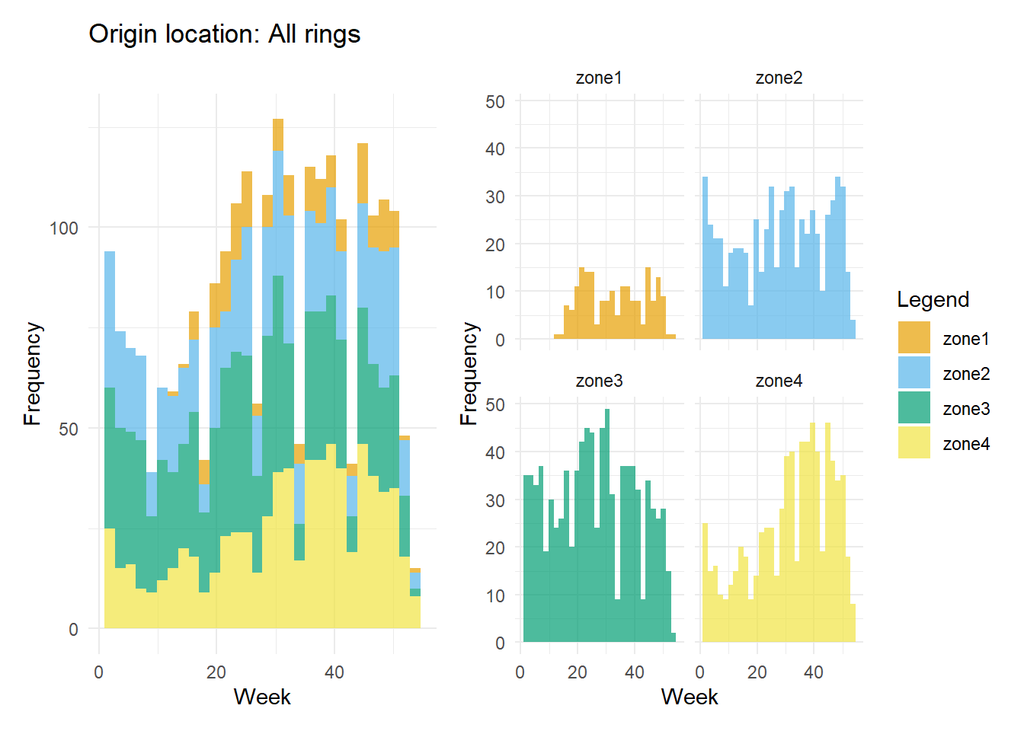

```r
# Color blind friendly palette :
cbp1 <- c("#999999", "#E69F00", "#56B4E9", "#009E73",
          "#F0E442", "#0072B2", "#D55E00", "#CC79A7")

# Set up color scheme for following geographical zone plots
zones <- sort(unique(shelf_rings$origin))
zone_cols <- cbp1[2:5]
names(zone_cols)  <- zones

# Generate plots
p11 <- ggplot(new_data, aes(x = week, fill = origin),
              binwidth = 40) +
  geom_histogram(alpha = 0.7) +
  scale_fill_manual('Legend', values = zone_cols) +
  xlab('Week') +
  ylab('Frequency')+
  labs(title = 'Origin location: All rings') +
  theme_minimal() +
  theme(legend.position = "none")
p1 <- ggplot(new_data, aes(x = week, fill = origin),
             binwidth = 40) +
  geom_histogram(alpha = 0.7) +
  scale_fill_manual('Legend', values = zone_cols) +
  xlab('Week') +
  ylab('Frequency')+
  #labs(title = 'Origin location: All rings') +
  theme(legend.position = "none") +
  theme_minimal()+
  facet_wrap(~origin)
p2<- ggplot(shelf_rings, aes(x = week, fill = origin), binwidth = 40) +
  geom_histogram(alpha = 0.7) +
  scale_fill_manual('Legend', values = zone_cols) +
  xlab('Week') +
  ylab('Frequency')+
  labs(title = 'Origin location: Shelf rings') +
  theme_minimal()
p2.2<- ggplot(shelf_rings, aes(x = week, fill = origin), binwidth = 40) +
  geom_histogram(alpha = 0.7) +
  scale_fill_manual('Legend', values = zone_cols) +
  xlab('Week') +
  ylab('Frequency')+
  labs(title = 'Origin location: Shelf rings') +
  theme_minimal() +
  theme(legend.position = "none")
p3 <-ggplot(shelf_rings, aes(x = week, fill = origin), binwidth = 40) +
  geom_histogram(alpha = 0.7) +
  scale_fill_manual('Legend', values = zone_cols) +
  xlab('Week') +
  ylab('Frequency')+
  #labs(title = 'Origin location: Shelf rings') +
  theme_minimal()+
  facet_wrap(~origin)

# Plot the figures
p11|p1 # All rings
```

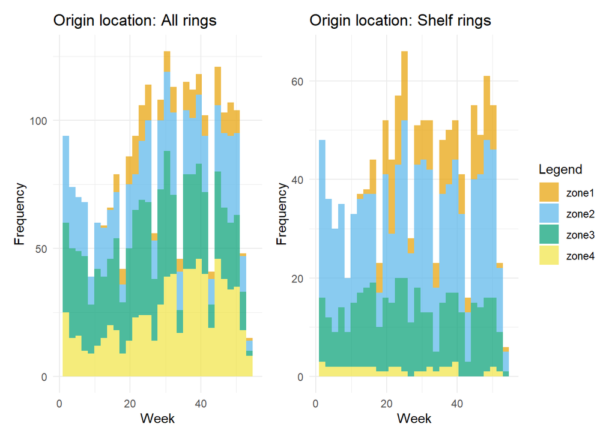

```r
p11 | p2 # All rings vs Shelf Rings
```

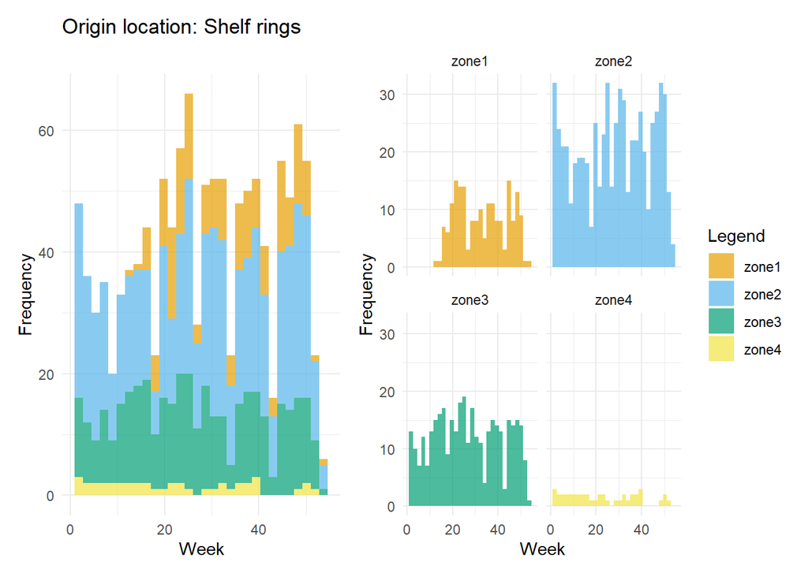

```r
p2.2 |p3 # Shelf rings
```

## Visualize: Zone of Origination

> Zone of origination for shelf rings occuring during the fishing season in good, average and poor years.

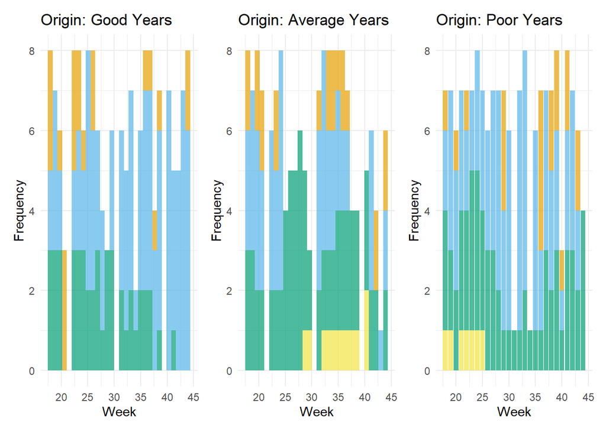

```r
dt <- shelf_rings_fs %>%
  dplyr::group_by(score, origin)%>%
  dplyr::tally()%>%
  dplyr::mutate(percent=n/sum(n))
#dt[c(12,13,14),1] <- c('G','G','G')
dt <- dt[-c(12:14),]
or_plot <- ggplot(data = dt,aes(x= origin, y = n, fill = score))+ geom_bar(stat="identity")+
  geom_text(aes(label=paste0(sprintf("%1.1f", percent*100),"%")),
            position=position_stack(vjust=0.5),
            colour="white", size = 2) +
  xlab('Zone of origination') +
  ylab('Number of Rings') +
  #labs(title = 'Origin across') +
  theme_minimal()

a <-ggplot(shelf_rings_fs %>% dplyr::filter(score == 'G'),
            aes(x = week, fill = origin)) +
  geom_histogram(alpha = 0.7) +
  scale_fill_manual('Legend', values = zone_cols) +
  ylim(0,8) +
  xlab('Week') +
  ylab('Frequency') +
  labs(title = 'Origin: Good Years') +
  theme_minimal()+
  theme(legend.position = "none")

aa <- ggplot(shelf_rings_fs %>% dplyr::filter(score == 'G'),
            aes(x = week, fill = origin)) +
  geom_histogram(alpha = 0.7) +
  scale_fill_manual('Legend', values = zone_cols) +
  ylim(0,8) +
  xlab('Week') +
  ylab('Frequency') +
  #labs(title = 'Origin: Good Years') +
  theme_minimal()+
  theme(legend.position = "none") +
  facet_wrap(~origin)


b <- ggplot(shelf_rings_fs %>% dplyr::filter(score == 'A'),
            aes(x = week, fill = origin)) +
  geom_histogram(alpha = 0.7) +
  scale_fill_manual('Legend', values = zone_cols) +
  ylim(0,8) +
  xlab('Week') +
  ylab('Frequency') +
  labs(title = 'Origin: Average Years') +
  theme_minimal()+
  theme(legend.position = "none")
bb <- ggplot(shelf_rings_fs %>% dplyr::filter(score == 'A'),
             aes(x = week, fill = origin)) +
  geom_histogram(alpha = 0.7) +
  scale_fill_manual('Legend', values = zone_cols) +
  ylim(0,8) +
  xlab('Week') +
  ylab('Frequency') +
  #labs(title = 'Origin: Average Years') +
  theme_minimal()+
  #theme(legend.position = "none") +
  facet_wrap(~ origin)

c <- ggplot(shelf_rings_fs %>% dplyr::filter(score == 'P'),
            aes(x = week, fill = origin)) +
  geom_bar(alpha = 0.7) +
  scale_fill_manual('Legend', values = zone_cols) +
  ylim(0,8) +
  xlab('Week') +
  ylab('Frequency') +
  labs(title = 'Origin: Poor Years') +
  theme_minimal()  +
  theme(legend.position = "none")

  cc <- ggplot(shelf_rings_fs %>% dplyr::filter(score == 'P'),
               aes(x = week, fill = origin)) +
  geom_histogram(alpha = 0.7) +
  scale_fill_manual('Legend', values = zone_cols) +
  ylim(0,8) +
  xlab('Week') +
  ylab('Frequency') +
  #labs(title = 'Origin: Poor Years') +
  theme_minimal() +
  facet_wrap(~ origin)

# o_num <-  shelf_rings_fs %>%
#   group_by(year, score, origin) %>%
#   summarise(number = length(unique(id)))
# o_num$prop <- o_num$number/ring_num$number
# o_num<-subset(o_num, year %in% c(2011:2019))
#
# g3<-ggplot(o_num %>% dplyr::filter(score == 'G'),
#        aes(x=year, y=number, fill = origin)) +
#   geom_bar(stat="identity") +
#   scale_fill_manual('Legend', values = zone_cols) +
#   ylim(0,15) +
#   xlab('Year') +
#   ylab('Number of rings') +
#   labs(title = 'Origin: Good Years') +
#   theme_minimal() +
#    theme(legend.position = "none") +
#   facet_wrap(~ origin)
#
# g4<-ggplot(o_num %>% dplyr::filter(score == 'P'),
#        aes(x=year, y=number, fill = origin)) +
#   geom_bar(stat="identity", position = 'fill') +
#   scale_fill_manual('Legend', values = zone_cols) +
#   ylim(0,15) +
#   xlab('Year') +
#   ylab('Number of rings') +
#   labs(title = 'Origin: Poor Years') +
#   theme_minimal() +
#   facet_wrap(~ origin)
#
# g3|g4

# Plot figures

a | b | c
```

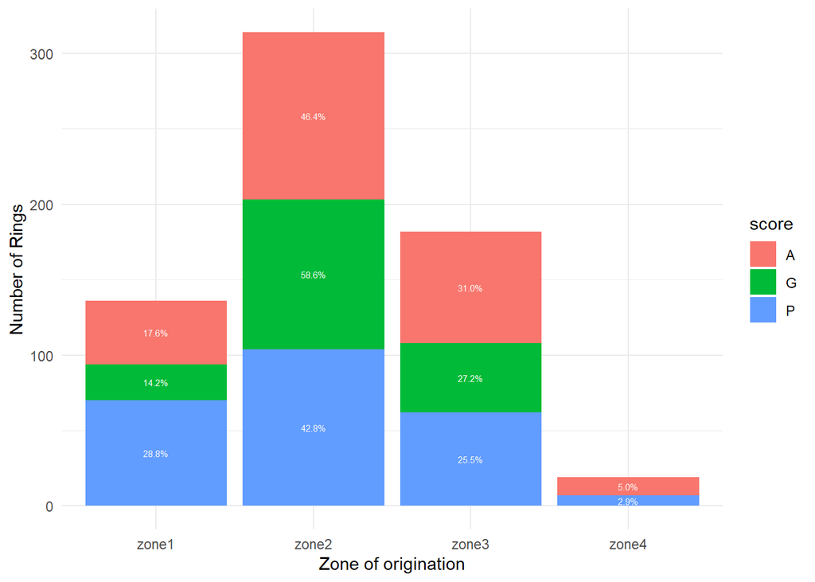

```r
or_plot
```

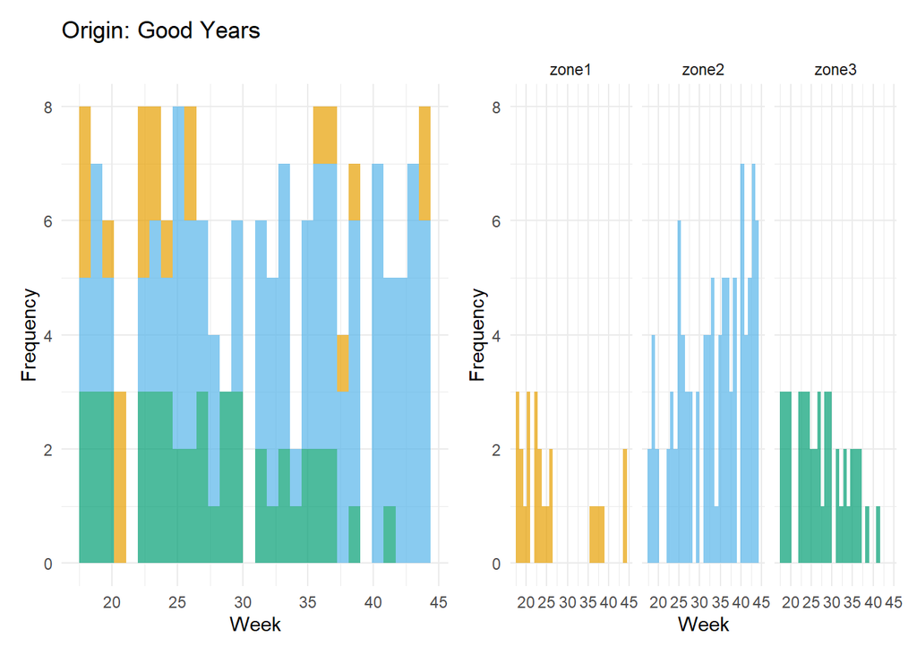

```r
a|aa
```

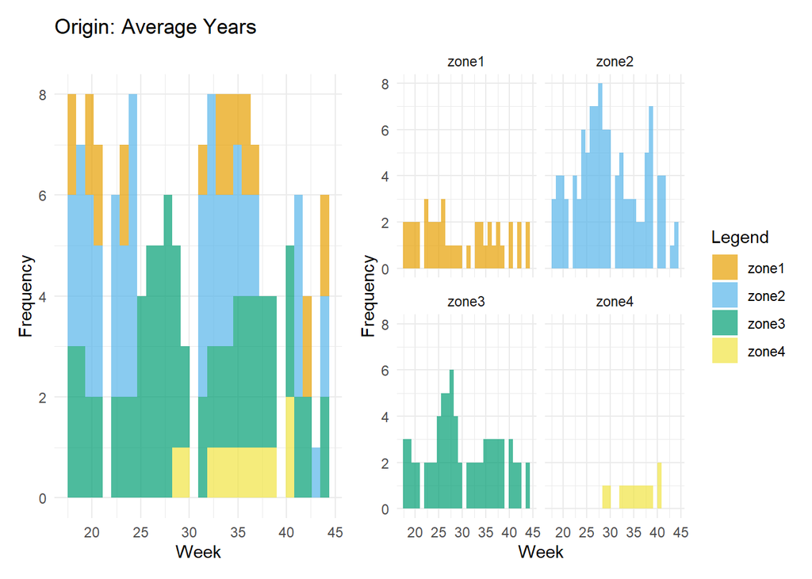

```r
b|bb
```

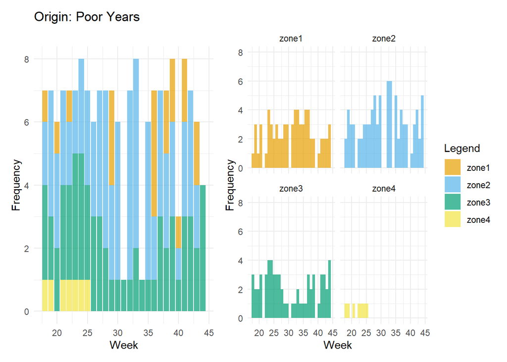

```r
c|cc
```

The above figures suggest that in **Poor** years - there is a higher frequency of rings born in Zone 2 and Zone 1 than in **Good** years. Rings born in these zones were found to have a higher probability of survival than those born in zones 3 or 4 (Silva_ea_20). This is consistent with previous findings about age.

### Quantify differences

```r
aov3.1 <- aov(year ~ origin, data = shelf_rings_fs)
Anova(aov3.1, type = 'III')
```

```
## Anova Table (Type III tests)
##
## Response: year
##                Sum Sq  Df    F value    Pr(>F)
## (Intercept) 580104506   1 8.1413e+07 < 2.2e-16 ***
## origin            172   3 8.0316e+00 2.893e-05 ***
## Residuals        4838 679
## ---
## Signif. codes:  0 '***' 0.001 '**' 0.01 '*' 0.05 '.' 0.1 ' ' 1
```

```r
TukeyHSD(aov3.1)
```

```
##   Tukey multiple comparisons of means
##     95% family-wise confidence level
##
## Fit: aov(formula = year ~ origin, data = shelf_rings_fs)
##
## $origin
##                     diff        lwr        upr     p adj
## zone2-zone1  0.933106649  0.2438838  1.6223295 0.0029198
## zone3-zone1  0.927510634  0.1698082  1.6852131 0.0091432
## zone4-zone1 -1.276775856 -2.9554458  0.4018941 0.2048002
## zone3-zone2 -0.005596015 -0.6286085  0.6174165 0.9999955
## zone4-zone2 -2.209882504 -3.8322155 -0.5875495 0.0027037
## zone4-zone3 -2.204286489 -3.8568751 -0.5516979 0.0035076
```

```r
aov3.2 <- aov(week ~ origin, data = shelf_rings_fs)
Anova(aov3.2, type = 'III')
```

```
## Anova Table (Type III tests)
##
## Response: week
##             Sum Sq  Df   F value Pr(>F)
## (Intercept) 130084   1 2252.5618 <2e-16 ***
## origin         189   3    1.0913 0.3521
## Residuals    39212 679
## ---
## Signif. codes:  0 '***' 0.001 '**' 0.01 '*' 0.05 '.' 0.1 ' ' 1
```

```r
table(shelf_rings_fs$origin, shelf_rings_fs$score)
```

```
##
##           A   G   P
##   zone1  42  24  70
##   zone2 111  99 104
##   zone3  74  46  62
##   zone4  12   0   7
```

```r
chisq.test(shelf_rings_fs$origin, shelf_rings_fs$score, correct=FALSE)
```

```
##
##  Pearson's Chi-squared test
##
## data:  shelf_rings_fs$origin and shelf_rings_fs$score
## X-squared = 27.442, df = 6, p-value = 0.0001196
```

## Visualize: Zone of Demise

> Zone of demise for shelf rings occuring during the fishing season in good, average and poor years.

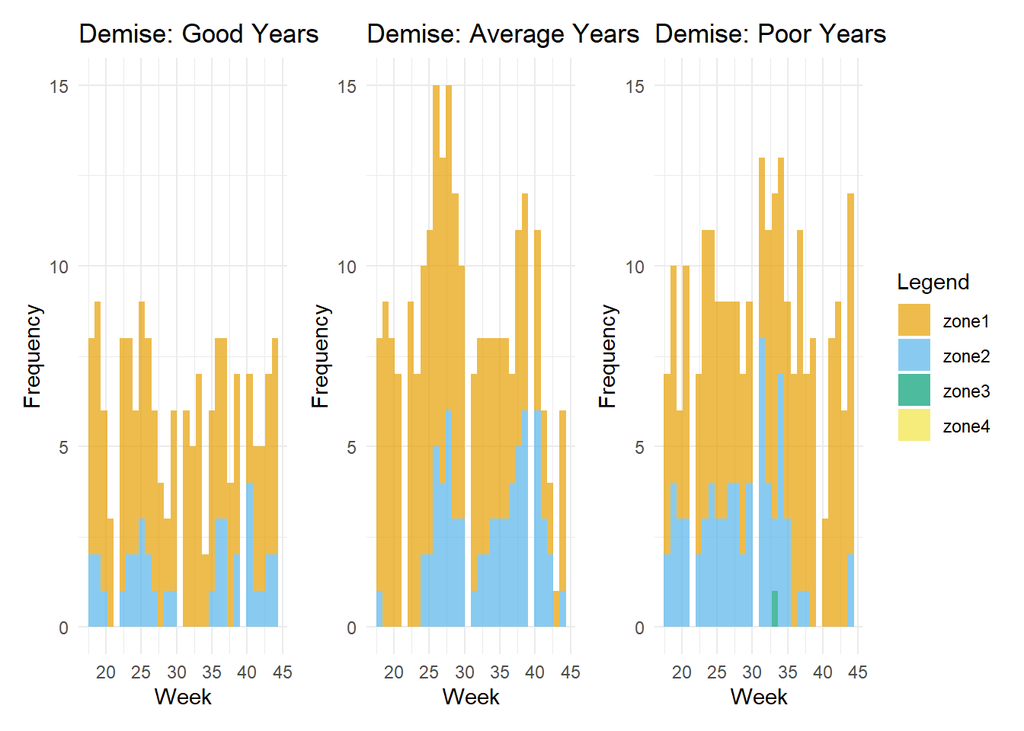

```r
dt <- shelf_rings_fs %>%
  dplyr::group_by(score, demise)%>%
  dplyr::tally()%>%
  dplyr::mutate(percent=n/sum(n))
#dt[c(12,13,14),1] <- c('G','G','G')
dt <- dt[-c(8:9),]
dm_plot <- ggplot(data = dt, aes(x= demise, y = n, fill = score))+ geom_bar(stat="identity")+
  geom_text(aes(label=paste0(sprintf("%1.1f", percent*100),"%")),
            position=position_stack(vjust=0.5),
            colour="white", size = 2) +
  xlab('Zone of demise') +
  ylab('Number of Rings') +
  #labs(title = 'Origin across') +
  theme_minimal()

a <- ggplot(shelf_rings_fs %>% dplyr::filter(score == 'G'),
       aes(x = week, fill = demise)) +
  geom_histogram(alpha = 0.7) +
  scale_fill_manual('Legend', values = zone_cols) +
  ylim(0,15) +
  xlab('Week') +
  ylab('Frequency') +
  labs(title = 'Demise: Good Years') +
  theme_minimal() +
  theme(legend.position = "none")



b <- ggplot(shelf_rings_fs %>% dplyr::filter(score == 'A'),
       aes(x = week, fill = demise)) +
  geom_histogram(alpha = 0.7) +
  scale_fill_manual('Legend', values = zone_cols) +
  ylim(0,15) +
  xlab('Week') +
  ylab('Frequency') +
  labs(title = 'Demise: Average Years') +
  theme_minimal() +
  theme(legend.position = "none")



c <- ggplot(shelf_rings_fs %>% dplyr::filter(score == 'P'),
       aes(x = week, fill = demise)) +
  geom_histogram(alpha = 0.7) +
  scale_fill_manual('Legend', values = zone_cols) +
  ylim(0,15) +
  xlab('Week') +
  ylab('Frequency') +
  labs(title = 'Demise: Poor Years') +
  theme_minimal()


a | b | c
```

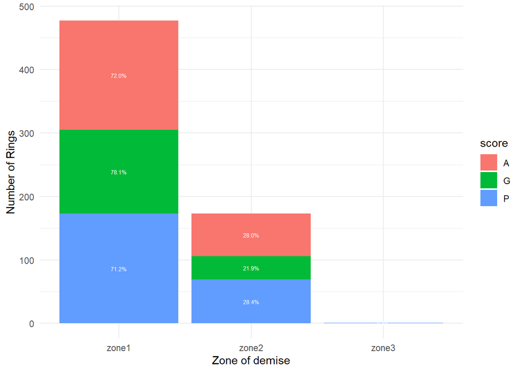

```r
dm_plot
```

### Quantify differences

```r
aov4.1 <- aov(year ~ demise, data = shelf_rings_fs)
Anova(aov4.1, type = 'III')
```

```
## Anova Table (Type III tests)
##
## Response: year
##                 Sum Sq  Df    F value  Pr(>F)
## (Intercept) 2042204516   1 2.8012e+08 < 2e-16 ***
## demise              52   2 3.5888e+00 0.02816 *
## Residuals         4958 680
## ---
## Signif. codes:  0 '***' 0.001 '**' 0.01 '*' 0.05 '.' 0.1 ' ' 1
```

```r
TukeyHSD(aov4.1)
```

```
##   Tukey multiple comparisons of means
##     95% family-wise confidence level
##
## Fit: aov(formula = year ~ demise, data = shelf_rings_fs)
##
## $demise
##                   diff       lwr         upr     p adj
## zone2-zone1 -0.6098937 -1.161866 -0.05792161 0.0260938
## zone3-zone1 -1.9562624 -8.304698  4.39217328 0.7494694
## zone3-zone2 -1.3463687 -7.706194  5.01345660 0.8726492
```

```r
aov4.2 <- aov(days_old ~ demise, data = shelf_rings_fs)
Anova(aov4.2, type = 'III')
```

```
## Anova Table (Type III tests)
##
## Response: days_old
##              Sum Sq  Df F value    Pr(>F)
## (Intercept) 3401387   1 857.018 < 2.2e-16 ***
## demise        92309   2  11.629 1.081e-05 ***
## Residuals   2698828 680
## ---
## Signif. codes:  0 '***' 0.001 '**' 0.01 '*' 0.05 '.' 0.1 ' ' 1
```

```r
TukeyHSD(aov4.2)
```

```
##   Tukey multiple comparisons of means
##     95% family-wise confidence level
##
## Fit: aov(formula = days_old ~ demise, data = shelf_rings_fs)
##
## $demise
##                  diff        lwr       upr     p adj
## zone2-zone1 -25.76333  -38.64199 -12.88467 0.0000094
## zone3-zone1 -75.23260 -223.35483  72.88963 0.4577352
## zone3-zone2 -49.46927 -197.85725  98.91870 0.7135815
```

```r
table(shelf_rings_fs$demise, shelf_rings_fs$score)
```

```
##
##           A   G   P
##   zone1 172 132 173
##   zone2  67  37  69
##   zone3   0   0   1
```

```r
chisq.test(shelf_rings_fs$demise, shelf_rings_fs$score, correct=FALSE)
```

```
##
##  Pearson's Chi-squared test
##
## data:  shelf_rings_fs$demise and shelf_rings_fs$score
## X-squared = 4.305, df = 4, p-value = 0.3663
```

## Visualize: Rings born in Zone 2, Demised in Zone 1

Silva and colleagues (2020) identified rings that originated in zone 2 and demised in zone 1 as having the highest survival probability. The following explores which and how many of the rings that are near the shelf during the fishing season are of this category of high survival probability (Z2Z1).

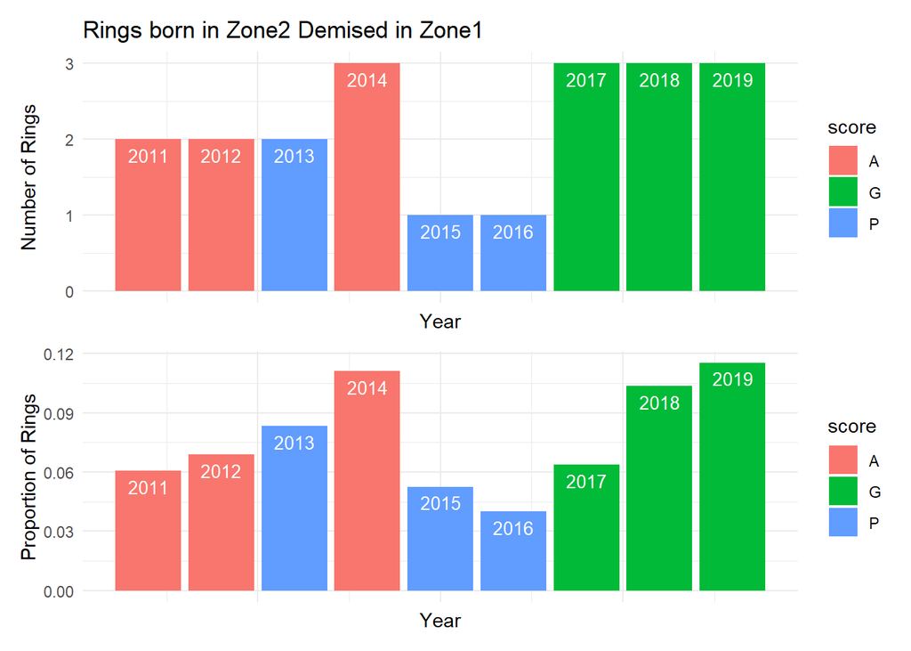

```r
# Calculate the number birthed in z2 and demised in z1 per year
z2z1 <- subset(shelf_rings_fs,
               origin == 'zone2' & demise == 'zone1' & year %in% c(2011:2019))
z2z1_num <-  z2z1 %>%
  group_by(year, score) %>%
  summarise(number = length(unique(id)))
z2z1_num$prop <- z2z1_num$number/ring_num$number

p1 = ggplot(z2z1_num, aes(x=year, y=number, fill = score)) +
  geom_bar(stat="identity" ) +
  xlab('Year') +
  ylab('Number of Rings') +
  labs(title = 'Rings born in Zone2 Demised in Zone1') +
  geom_text(aes(label=year), vjust=1.6, color="white", size=3.5)+
  theme_minimal() +
  theme(axis.text.x=element_blank())


p2 = ggplot(z2z1_num, aes(x=year, y=prop, fill = score)) +
  geom_bar(stat="identity" ) +
  xlab('Year') +
  ylab('Proportion of Rings') +
  #labs(title = 'Proportion of rings born in Zone2 Demised in Zone1') +
  geom_text(aes(label=year), vjust=1.6, color="white", size=3.5)+
  theme_minimal()+
  theme(axis.text.x=element_blank())


p1/p2
```

### Quantify

```r
table(z2z1_num$number, z2z1_num$score)
```

```
##
##     A G P
##   1 0 0 2
##   2 2 0 1
##   3 1 3 0
```

```r
aov5.1 <- aov(number ~ score, data = z2z1_num)
Anova(aov5.1, type = 'III')
```

```
## Anova Table (Type III tests)
##
## Response: number
##              Sum Sq Df F value    Pr(>F)
## (Intercept) 16.3333  1    73.5 0.0001383 ***
## score        4.2222  2     9.5 0.0138240 *
## Residuals    1.3333  6
## ---
## Signif. codes:  0 '***' 0.001 '**' 0.01 '*' 0.05 '.' 0.1 ' ' 1
```

```r
TukeyHSD(aov5.1)
```

```
##   Tukey multiple comparisons of means
##     95% family-wise confidence level
##
## Fit: aov(formula = number ~ score, data = z2z1_num)
##
## $score
##           diff        lwr        upr     p adj
## G-A  0.6666667 -0.5143127  1.8476460 0.2693505
## P-A -1.0000000 -2.1809794  0.1809794 0.0901060
## P-G -1.6666667 -2.8476460 -0.4856873 0.0116748
```

```r
aov5.2 <- aov(prop ~ score, data = z2z1_num)
Anova(aov5.2, type = 'III')
```

```
## Anova Table (Type III tests)
##
## Response: prop
##                Sum Sq Df F value   Pr(>F)
## (Intercept) 0.0193094  1 29.5883 0.001603 **
## score       0.0019261  2  1.4757 0.301143
## Residuals   0.0039156  6
## ---
## Signif. codes:  0 '***' 0.001 '**' 0.01 '*' 0.05 '.' 0.1 ' ' 1
```

## Extracting data from indivdual Warm Core Rings

1. Create polygon representing WCR in space
2. Extract chl from ring (and buffering location)
3. Determine angle from fishing point to ring

```r
# *** do I want to use years or ring id? ***
for(i in 1:length(unq_shelf_rings_fs)){
  tmp <- subset(shelf_rings_fs, id == unq_shelf_rings_fs[i])
  weeks <- sort(unique(tmp$week))
  for(k in 1:length(bricks)){
    btmp <- brick(bricks[k])
    btmp@data@names <- as.numeric(c(1:52))
    if(substr(bricks[k], start =  82, stop =  83) == substr(years[i], start =  3, stop =  4)){
      for(j in 1:length(weeks)){
        tmp2 <- subset(tmp, week == weeks[j])
        #coords <- data.frame(x = tmp2$lon, y = tmp2$lat)
        ring = circle.polygon(tmp2$lon, tmp2$lat, tmp2$radius,
                              poly.type = "gc.earth", units = 'km')
        coords <- data.frame(x = ring$lon, y = ring$lat)
        sp_ring <- SpatialPoints(coords)
        rtmp = raster::subset(btmp, which(btmp@data@names == weeks[j]))
        image(rtmp, main = paste0('Week',weeks[j])) # quick visual check
        ring_chl <- extract(rtmp, sp_ring, method='bilinear')
        locs <- which(cbwk$YEAR == years[i] & cbwk$WEEK == weeks[j]) # Change to correct DF
        cbwk$ring_chl[locs] <- ring_chl

      }
    }
  }



 # create a circle
U2020.40 <- subset(df, id == 'U2020' & week == 40)
c1 = circle.polygon(U2020.40$lon,U2020.40$lat, U2020.40$radius,
                   poly.type = "gc.earth", units = 'km')

# Plot on map
op <- par(mar = c(3, 5, 5, 5) + 0.1, oma = c(1, 1, 1, 1))
maps::map("mapdata::worldHires", fill = TRUE, col = "wheat3",
          xlim = lon.range, ylim = lat.range)
points(E2015.13$lon, E2015.13$lat, pch = 19, col = "goldenrod")
polygon(c1, border = "goldenrod", lwd = 3)
points(fish[,1], fish[,2], pch = 19, col = 'black', cex = 2)
lat.lon.axes(n = 3)
box(lwd = 2)


# plot the track of ring
plot(makeLine(tmp), type='l',  main = paste0('WCR_ID :',unq_shelf_rings_fs[i]))
points(tmp)
}

# Plot polygon of ring
for(j in 1:length(years)){
  tmp <- subset(shelf_rings_fs, year == years[j])
  weeks = sort(unique(tmp$week))
  for(i in 1:unq_shelf_rings_fs){
    tmp2 <- subset(shelf_rings_fs, id == unq_shelf_rings_fs[i])
    for(k in 1:length(weeks)){
      tmp3 <- subset(tmp2, week == weeks[k])
      c = circle.polygon(tmp3$lon, tmp3$lat, tmp3$radius,
                         poly.type = "gc.earth", units = 'km')
      maps::map("mapdata::worldHires", fill = TRUE, col = "wheat3",
                xlim = lon.range, ylim = lat.range)
      points(tmp3$lon, tmp3$lat, pch = 19, col = "red")
      polygon(c1, border = "red", lwd = 3)
      lat.lon.axes(n = 3)
      box(lwd = 2)

    }
  }
}


# Generate
# (i) distance from fishing point to ring
library(useful)


t3 = c3[nrow(c3)/4,c(1,2)] # 90 degrees

fish = data.frame(lat = c(42.85712167,  42.80302, 42.85641333, 42.854875,   42.78498833,
                          42.80439, 42.85678333, 42.804105, 42.86433333, 42.83158, 42.776335,
                          42.83301167, 42.852615),
                  lon = c(-70.652395, -70.64875333, -70.644765, -70.66094667,
                          -70.64431667,-70.65403333,-70.65253,-70.65158667,-70.63724667,
                          -70.66055333,-70.63993,-70.65673333,-70.65805667))

fishy <- fish[1,c(2,1)]
# Plot polygon and fishing points
maps::map("mapdata::worldHires", fill = TRUE, col = "wheat3",
          xlim = lon.range, ylim = lat.range)
polygon(c21, border = "goldenrod", lwd = 3)
points(fishy$lon, fishy$lat, pch = 17, col = "black", cex = 1.3)
points(c3[1,1], c3[1,2], pch = 19, col = "red") # 270 degrees
points(t3[1], t3[2], pch = 19, col = "blue")


# Calculate angle between fishing point and ring to determine orientation

To = c3[nrow(c3)/4,c(1,2)]
From = as.matrix(fishy)
df2 = To - From
results = cart2pol(df2[,1], df2[,2], degrees = T)
```